# Winning the Battle for Wesnoth

```
## <environment: R_GlobalEnv>
```

## Battle for Wesnoth

[figure not shown]

- Turn-based Strategy
- Open-sourced and runs on all OS (even Linux!)
- Continuous Development and Evolution

## Game Background

- There are 244 different units spread over 7 factions on 72 maps
- Combat contains random elements
- 17 official campaigns, more self-made ones and plenty of lore for the fanboys

[figure not shown]

## The Data Set

- 4.5GB of JSON events
- 27286 individual games
- 2738 individual players
- For analysis, only meta data was used
- Data needed a little tidying

```
## # A tibble: 6 x 6
##   stats.advances.… stats.deaths.dr… stats.deaths.dr… stats.deaths.dr…
##              <dbl>            <dbl>            <dbl>            <dbl>
## 1               NA                1                3                1
## 2                1               NA               NA               NA
## 3               NA               NA               NA               NA
## 4               NA               NA               NA               NA
## 5               NA               NA               NA               NA
## 6               NA               NA               NA               NA
## # ... with 2 more variables: stats.deaths.drake_glider <dbl>,
## #   stats.deaths.saurian_augur <dbl>
```

## Questions

- Are the faction choices meaningful?
- Is the starting position meaningful?
- What are good strategies?

## Questions

- **Are the faction choices meaningful?**
- **Is the starting position meaningful?**
- What are good strategies?

## Factions

- Each Player chooses a faction
- Calculate adjusted win ratio for fair coin flips with \(M\) positive outcomes

\[ z = \frac{M - <M>}{\sigma_M} = \frac{2M - N}{\sqrt{N}} \] - In principle hierarchical extension to leaders

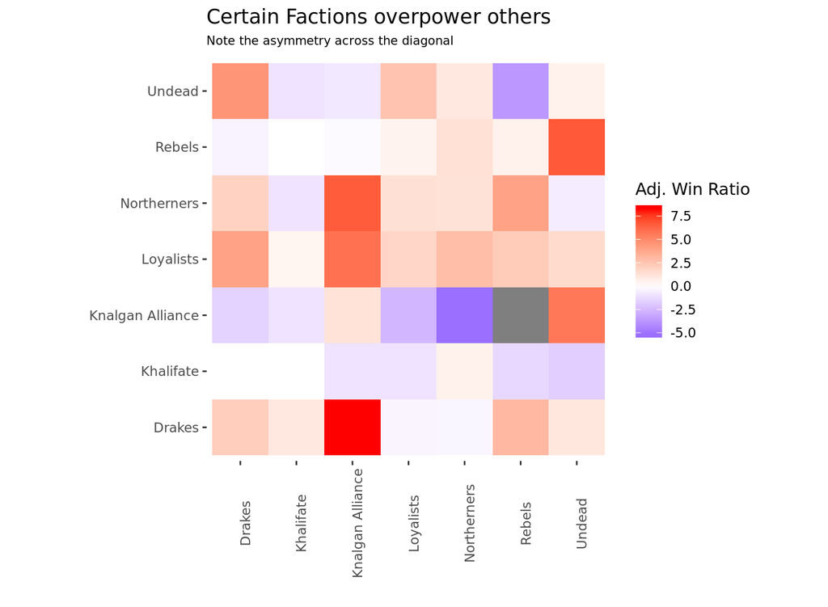

- There are rock-paper-scissor relations such as Loyalists > Knalgan Alliance > Undead > Loyalists

## Testing the Assumptions

- Infer the probability distribution of the base probability of each group.
- Beta distribution \[ Beta(x, \alpha, \beta) = \frac{1}{B(\alpha, \beta)} = x^{\alpha -1} (1-x)^{\beta - 1} \]

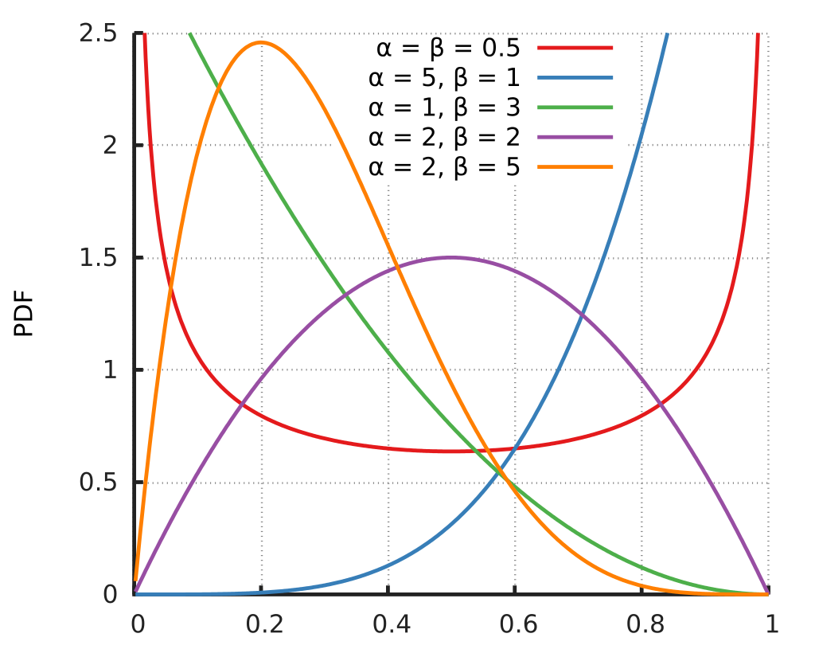

- Larger \(\alpha\) and \(\beta\) means narrower distributions
- Empirically estimate parameters for each group as \(\alpha = M + 1\) and \(\beta = N-M + 1\), then calculate plausible intervals

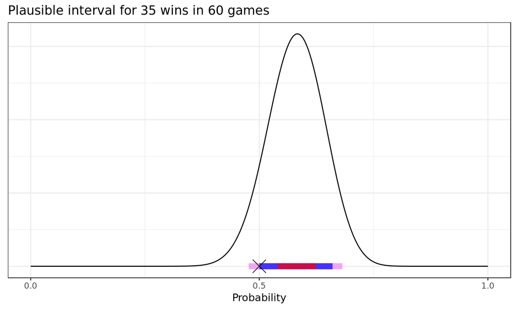

- In about 50% of cases p=0.5 should be in 50% likelihood interval, 80% in 80% likelihood interval, … (Data Folds allow for natural variation)

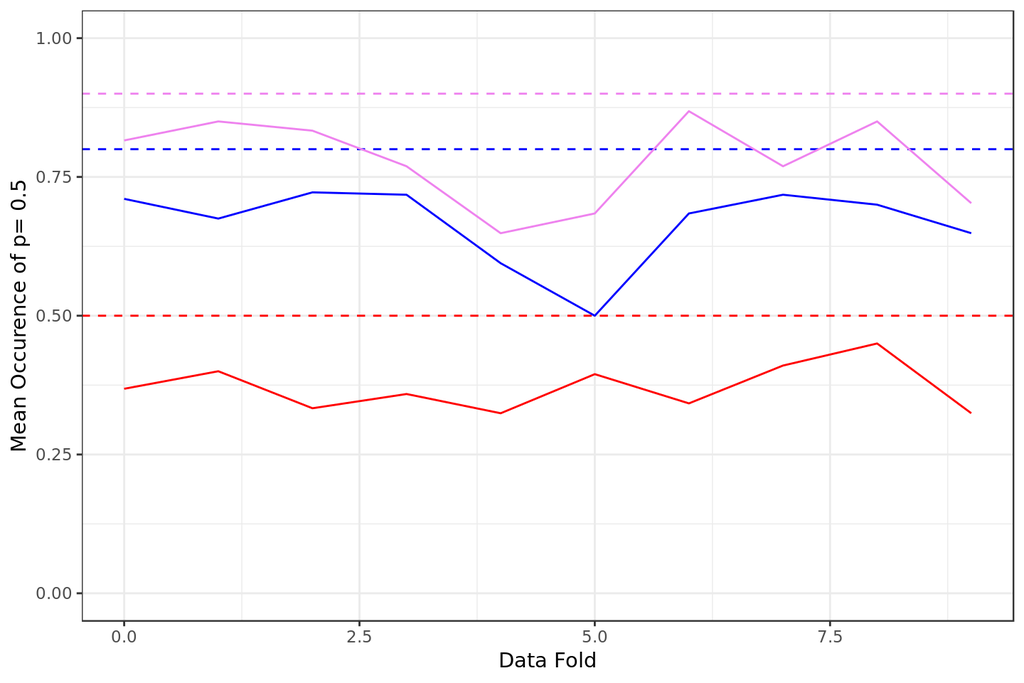

## Faction-Leader Hierarchies

- L1 feature importance suggests that factions are more impactful than leaders
- Big bands are faction combinations, sub-bands are leader combinations

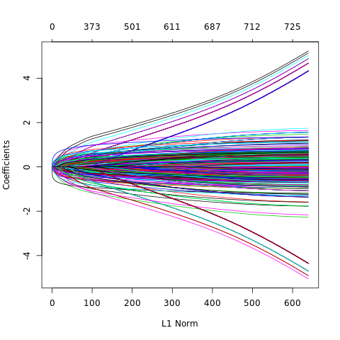

- Leaders are not exact subset of factions

## Modeling

- Built symmetrised features for factions, leaders, and map position
- Added retroed elo difference (strongest feature)
- Logistic Regression as good as xgboost
- Shallow trees with few interactions, but uplift due to categorical features
- AUC of 0.74 and accuracy of 70% on unseen test data